# IODS course project

Juho Vehviläinen

# Introduction to Open Data Science - Course Project

# About the project

*Write a short description about the course and add a link to your GitHub repository here. This is an R Markdown (.Rmd) file so you should use R Markdown syntax.*

```r
# This is a so-called "R chunk" where you can write R code.

date()
```

```
## [1] "Tue Dec 12 11:43:34 2023"
```

## Intro

I have experience of programming in **Python**, **Fortran**, **C**, and **Matlab** and scripting in several languages, however, I have not used R that much. Also, my conding skills have been diminished in my time doing medicine. The syntax seems familiar in some ways. The RStudio looks useful and the Git integration is a nice modern way of version control. I would like to learn to use more R than SPSS and Stata as the latter are proprietary software and R is much more versatile. I found the course from the pool of courses suitable for doctoral studies. As I am missing 5 ECTS and the course is just that, I thought that this would be useful and fun.

As I mentioned, the syntax has some similarities, especially with Matlab and perhaps LaTeX as well. It is always somewhat an effort to move from one language to another and try to remember the small things. Fortunately the bigger picture is quite the same as computers work as the way they do.

## GitHub repository

Link to my IODS-project GitHub repository https://github.com/juhove/IODS-project

### GitHub pages

Link to my IODS-project GitHub course diary https://juhove.github.io/IODS-project/

# Assignment 2, second week

*Describe the work you have done this week and summarize your learning.*

- Describe your work and results clearly.
- Assume the reader has an introductory course level understanding of writing and reading R code as well as statistical methods.
- Assume the reader has no previous knowledge of your data or the more advanced methods you are using.

```r
date()
```

```
## [1] "Tue Dec 12 11:43:34 2023"
```

## 1.

Read data that was written as a CSV file in the previous exercise

```r
# Load libraries
suppressWarnings({
library(tidyverse)
library(readr)
library(finalfit)
library(dplyr)})
data_read_2014 <- read_csv("learning2014.csv")
```

Check the beginning of the data

```r
# Check the beginning of the data
head(data_read_2014)
```

```
## # A tibble: 6 × 7
##   gender   Age Attitude  Deep  Stra  Surf Points
##   <chr>  <dbl>    <dbl> <dbl> <dbl> <dbl>  <dbl>
## 1 F         53      3.7  3.58  3.38  2.58     25
## 2 M         55      3.1  2.92  2.75  3.17     12
## 3 F         49      2.5  3.5   3.62  2.25     24
## 4 M         53      3.5  3.5   3.12  2.25     10
## 5 M         49      3.7  3.67  3.62  2.83     22
## 6 F         38      3.8  4.75  3.62  2.42     21
```

```r
# Some more indepth information regarding the data (variable types)
spec(data_read_2014)
# Dimensions of the data as a vector
dim_data_read_2014 <- dim(data_read_2014)
dim_data_read_2014
```

```
## [1] 166   7
```

```r
# Missing data, mean, sd, IQR, min/max values
ff_glimpse(data_read_2014)
```

```
## $Continuous
##             label var_type   n missing_n missing_percent mean  sd  min
## Age           Age    <dbl> 166         0             0.0 25.5 7.8 17.0
## Attitude Attitude    <dbl> 166         0             0.0  3.1 0.7  1.4
## Deep         Deep    <dbl> 166         0             0.0  3.7 0.6  1.6
## Stra         Stra    <dbl> 166         0             0.0  3.1 0.8  1.2
## Surf         Surf    <dbl> 166         0             0.0  2.8 0.5  1.6
## Points     Points    <dbl> 166         0             0.0 22.7 5.9  7.0
##          quartile_25 median quartile_75  max
## Age             21.0   22.0        27.0 55.0
## Attitude         2.6    3.2         3.7  5.0
## Deep             3.3    3.7         4.1  4.9
## Stra             2.6    3.2         3.6  5.0
## Surf             2.4    2.8         3.2  4.3
## Points          19.0   23.0        27.8 33.0
##
## $Categorical
##         label var_type   n missing_n missing_percent levels_n levels
## gender gender    <chr> 166         0             0.0        2      -
##        levels_count levels_percent
## gender            -              -
```

## 2.

Plot basic histograms of the variables

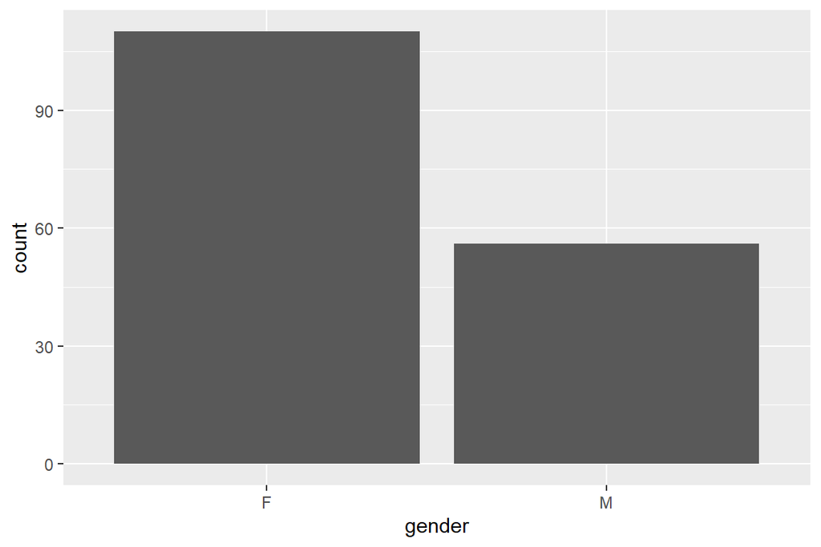

```r
data_read_2014 %>% ggplot(aes(x = gender)) + geom_bar()
```

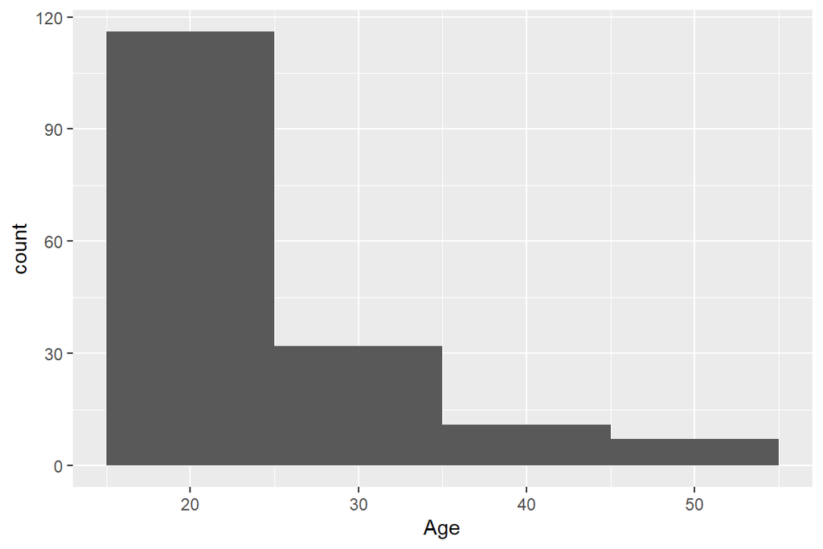

```r
# Binning the ages by ten years
data_read_2014 %>% ggplot(aes(x = Age)) + geom_histogram(binwidth = 10)
```

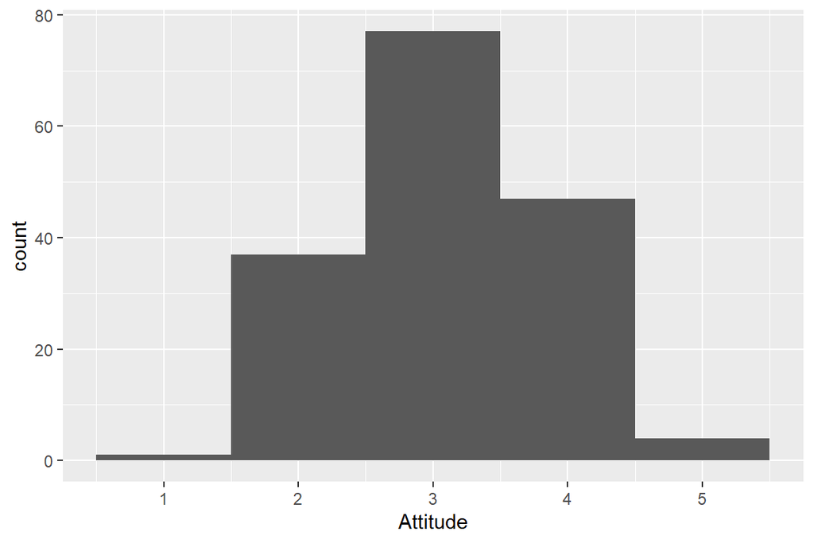

```r
data_read_2014 %>% ggplot(aes(x = Attitude)) + geom_histogram(binwidth = 1)
```

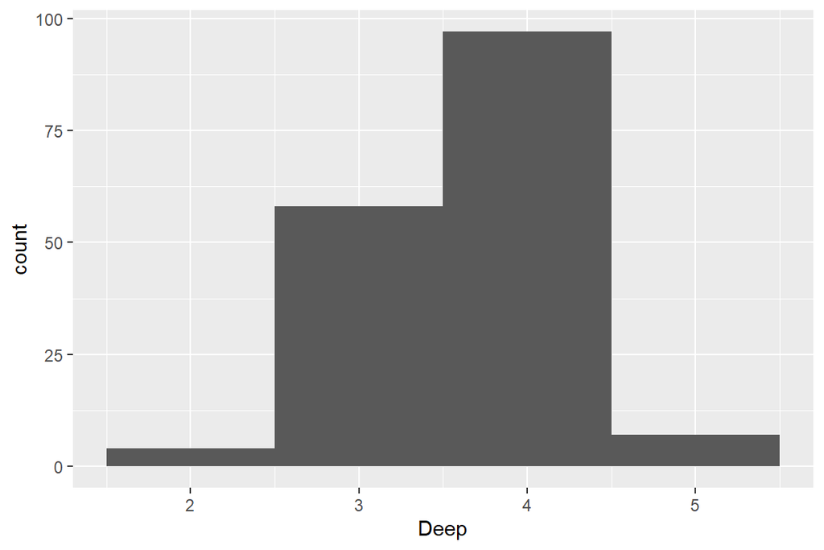

```r
data_read_2014 %>% ggplot(aes(x = Deep)) + geom_histogram(binwidth = 1)
```

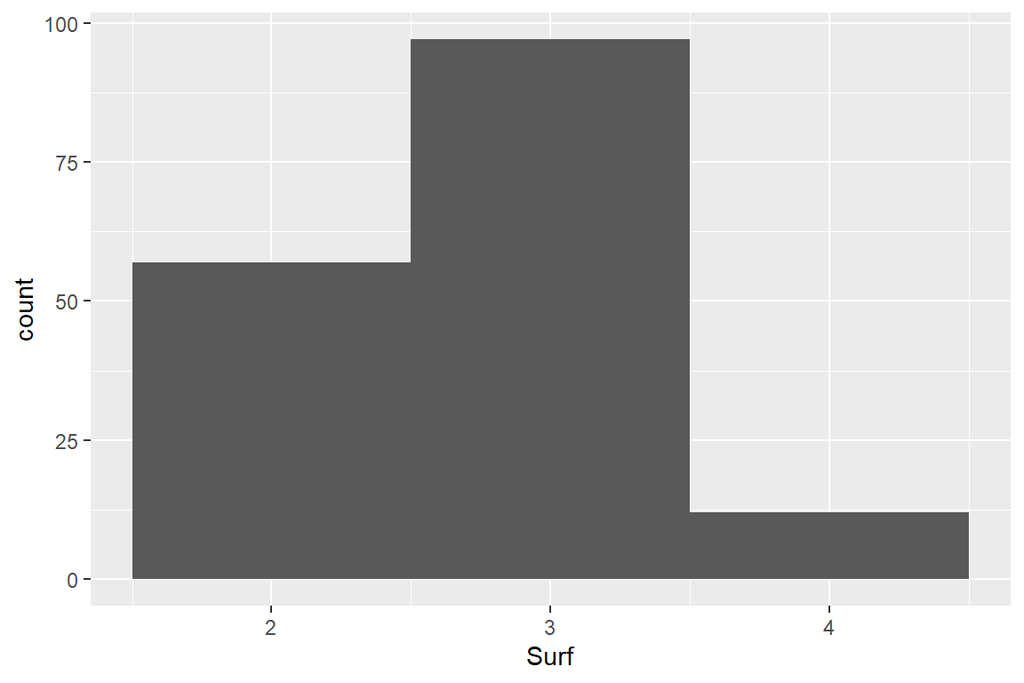

```r
data_read_2014 %>% ggplot(aes(x = Surf)) + geom_histogram(binwidth = 1)
```

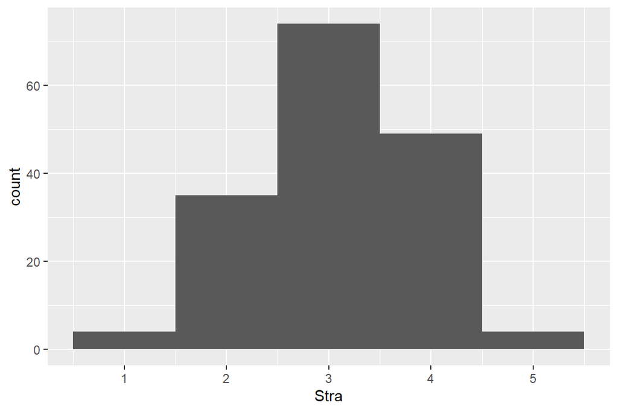

```r
data_read_2014 %>% ggplot(aes(x = Stra)) + geom_histogram(binwidth = 1)
```

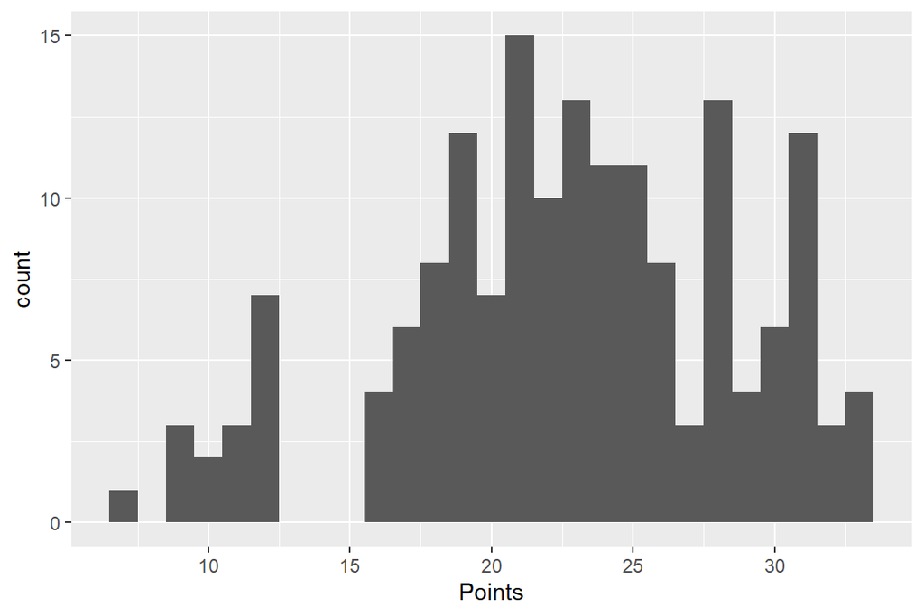

```r
data_read_2014 %>% ggplot(aes(x = Points)) + geom_histogram(binwidth = 1)
```

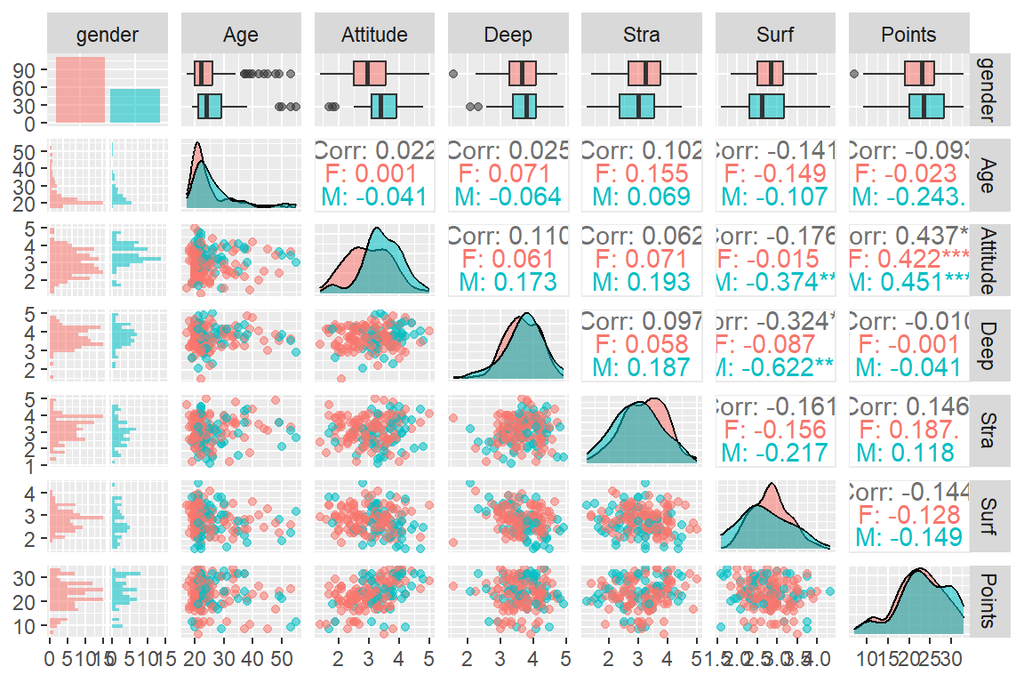

```r
library(ggplot2)
library(GGally)
draw_plot <- ggpairs(data_read_2014, mapping = aes(col= gender, alpha = 0.3), lower = list(combo = wrap("facethist", bins = 20)))

# draw the plot
draw_plot
```

Plots show that

Number of women is almost double compared to number of men.

Age is skewed towards younger population (as with students is quite extected).

Attitude and Strategic (Stra) approach look like normally distributed.

Points starts as normally distributed when starting from the left side (that might be expected for test scores), however, there are concentrations of higher points achieved between 27 and 32.

```r
data_read_2014 %>% group_by(gender) %>% summarise_all(mean)
```

```
## # A tibble: 2 × 7
##   gender   Age Attitude  Deep  Stra  Surf Points
##   <chr>  <dbl>    <dbl> <dbl> <dbl> <dbl>  <dbl>
## 1 F       24.9     2.99  3.66  3.20  2.83   22.3
## 2 M       26.8     3.44  3.72  2.96  2.70   23.5
```

```r
data_read_2014 %>% group_by(gender) %>% summarise_all(sd)
```

```
## # A tibble: 2 × 7
##   gender   Age Attitude  Deep  Stra  Surf Points
##   <chr>  <dbl>    <dbl> <dbl> <dbl> <dbl>  <dbl>
## 1 F       7.36    0.725 0.535 0.748 0.458   5.83
## 2 M       8.43    0.646 0.592 0.801 0.642   6.01
```

```r
# Create information of age groups (Agegrp), 10 year intervals
data_ageG <- data_read_2014 %>% mutate(Agegrp = cut(Age, breaks = seq(0,70, by = 10)))

# Calculate mean of continuous variables diveded by age groups
data_ageG %>% group_by(Agegrp) %>% select(-gender) %>% summarize_all(mean)
```

```
## # A tibble: 5 × 7
##   Agegrp    Age Attitude  Deep  Stra  Surf Points
##   <fct>   <dbl>    <dbl> <dbl> <dbl> <dbl>  <dbl>
## 1 (10,20]  19.6     3.06  3.64  3.12  2.86   21.6
## 2 (20,30]  23.4     3.16  3.66  3.04  2.82   23.2
## 3 (30,40]  35.0     3.17  3.90  3.39  2.56   24
## 4 (40,50]  46.7     3.1   3.62  3.46  2.63   20.1
## 5 (50,60]  53.7     3.43  3.33  3.08  2.67   15.7
```

```r
# Calculate mean of continuous variables diveded by age groups and gender
data_ageG %>% group_by(Agegrp, gender) %>% summarize_all(mean)
```

```
## # A tibble: 10 × 8
## # Groups:   Agegrp [5]
##    Agegrp  gender   Age Attitude  Deep  Stra  Surf Points
##    <fct>   <chr>  <dbl>    <dbl> <dbl> <dbl> <dbl>  <dbl>
##  1 (10,20] F       19.5     3.03  3.64  3.15  2.88   22.2
##  2 (10,20] M       19.7     3.3   3.64  2.83  2.64   14.7
##  3 (20,30] F       23.2     2.96  3.62  3.15  2.85   22.4
##  4 (20,30] M       23.8     3.43  3.72  2.90  2.79   24.4
##  5 (30,40] F       34.7     3     3.88  3.35  2.70   23.1
##  6 (30,40] M       35.5     3.57  3.97  3.48  2.24   26.2
##  7 (40,50] F       45.6     2.9   3.57  3.68  2.73   19.6
##  8 (40,50] M       49.5     3.6   3.75  2.94  2.38   21.5
##  9 (50,60] F       53       3.7   3.58  3.38  2.58   25
## 10 (50,60] M       54       3.3   3.21  2.94  2.71   11
```

## 3. & 4.

Explanatory variables: Age, Attitude, gender Dependent or outcome: Points

```r
library(tidyverse)
library(purrr)
library(ggfortify)
# Linear model fit
fit_points <- data_read_2014 %>% lm(Points ~  Age +Attitude + gender, data = .)
fit_points
```

```
##
## Call:
## lm(formula = Points ~ Age + Attitude + gender, data = .)
##
## Coefficients:
## (Intercept)          Age     Attitude      genderM
##    13.42910     -0.07586      3.60657     -0.33054
```

```r
# Important values of the model from summary function (e.g. model performance)
summary(fit_points)
```

```
##
## Call:
## lm(formula = Points ~ Age + Attitude + gender, data = .)
##
## Residuals:
##      Min       1Q   Median       3Q      Max
## -17.4590  -3.3221   0.2186   4.0247  10.4632
##
## Coefficients:
##             Estimate Std. Error t value Pr(>|t|)
## (Intercept) 13.42910    2.29043   5.863 2.48e-08 ***
## Age         -0.07586    0.05367  -1.414    0.159
## Attitude     3.60657    0.59322   6.080 8.34e-09 ***
## genderM     -0.33054    0.91934  -0.360    0.720
## ---
## Signif. codes:  0 '***' 0.001 '**' 0.01 '*' 0.05 '.' 0.1 ' ' 1
##
## Residual standard error: 5.315 on 162 degrees of freedom
## Multiple R-squared:  0.2018, Adjusted R-squared:  0.187
## F-statistic: 13.65 on 3 and 162 DF,  p-value: 5.536e-08
```

According to this linear model gender and age were not statistically significant, but Attitude was p<0.001 (Pr 8.34e-09). Multiple R-squared (model fit) was 0.2018.

New try with just Attitude as the only explanatory variable

```r
fit_points2 <- data_read_2014 %>% lm(Points ~ Attitude, data = .)

# Model parameters, model performance
summary(fit_points2)
```

```
##
## Call:
## lm(formula = Points ~ Attitude, data = .)
##
## Residuals:
##      Min       1Q   Median       3Q      Max
## -16.9763  -3.2119   0.4339   4.1534  10.6645
##
## Coefficients:
##             Estimate Std. Error t value Pr(>|t|)
## (Intercept)  11.6372     1.8303   6.358 1.95e-09 ***
## Attitude      3.5255     0.5674   6.214 4.12e-09 ***
## ---
## Signif. codes:  0 '***' 0.001 '**' 0.01 '*' 0.05 '.' 0.1 ' ' 1
##
## Residual standard error: 5.32 on 164 degrees of freedom
## Multiple R-squared:  0.1906, Adjusted R-squared:  0.1856
## F-statistic: 38.61 on 1 and 164 DF,  p-value: 4.119e-09
```

This yields a slightly lower (0.1906) Multiple R-squared, but the difference is small. This suggests that other than Attitude does not have much effect on the model performance.

**Residuals** mean the difference between the model prediction and the actual values of Points.

**Estimates** are the coefficients for the linear model.

The first linear model here is in the following form Points = Intercept (Estimate) + Age* (Estimate) + Attitude* (Estimate) + gender* (Estimate)

The second linear model here is in the following form Points = Intercept (Estimate) + Attitude* (Estimate)

**Standard Error** is the standard error of the estimate. The standard error can be used to calculate the confidence intervals, e.g., 95% if the data is normally distributed and model assumptions hold, e.g., modeled value and the explanatory variable have indeed linear relationship.

**t value** is Estimate divided by Standard error.

**Pr(>|t|)** is the p-value for the individual coefficients. If the probability is low enough (arbitrary, usually p<0.05 or p<0.01) we can reject the null hypothesis. In this case, the null hypothesis is that the coefficient (Estimate) is 0.

**Multiple R-squared** is a measure of how well the model fits into the data (what proportion of the variance is explained by the model).

The Estimate of Attitude in the linear model above is 3.5255. This would mean that the higher the value of Attitude, higher the Points. The Attitude means a numeral value of global attitude toward statistics. My interpretation of this is that students who score higher in the questions concerning attitudes towards statistics will eventually learn the subject better and score higher in the test (higher Points).

In both models the Multiple R-squared values are close to each other (0.2018 vs. 0.1906). The bit higher goodness of fit in the first model with three explanatory variables is probably explained mainly by the Age that although not statistically significant (p = 0.159) does have some influence. When compared model with Age+Attitude vs. Attitude+Gender (not in the code), the former fits better.

## 5. Diagnostic plots

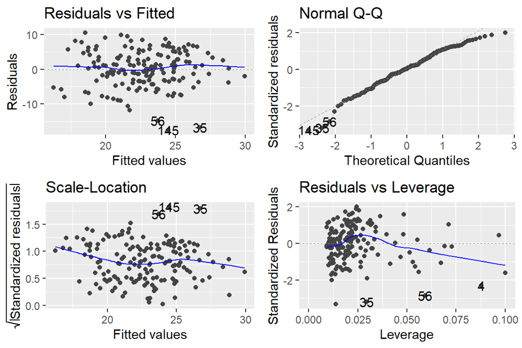

```r
# Diagnostic plots (Age + Attitude + Gender vs. Points)
autoplot(fit_points)
```

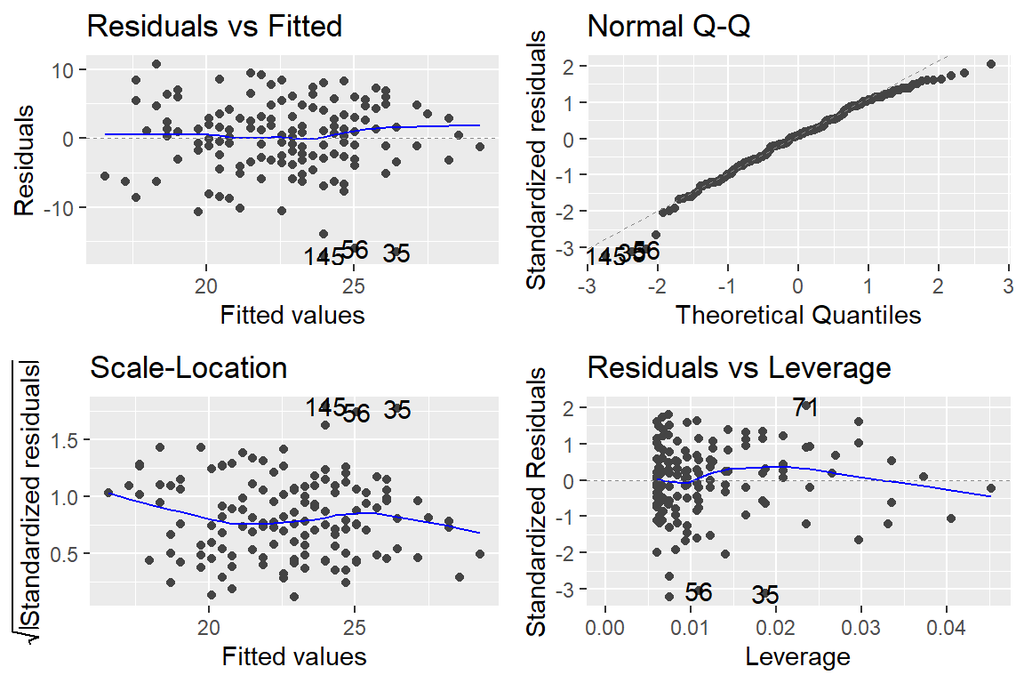

```r
# Diagnostic plots (Attitude vs. Points)
autoplot(fit_points2)
```

Larger plot to check Cook’s distance

(Age + Attitude + Gender vs. Points)

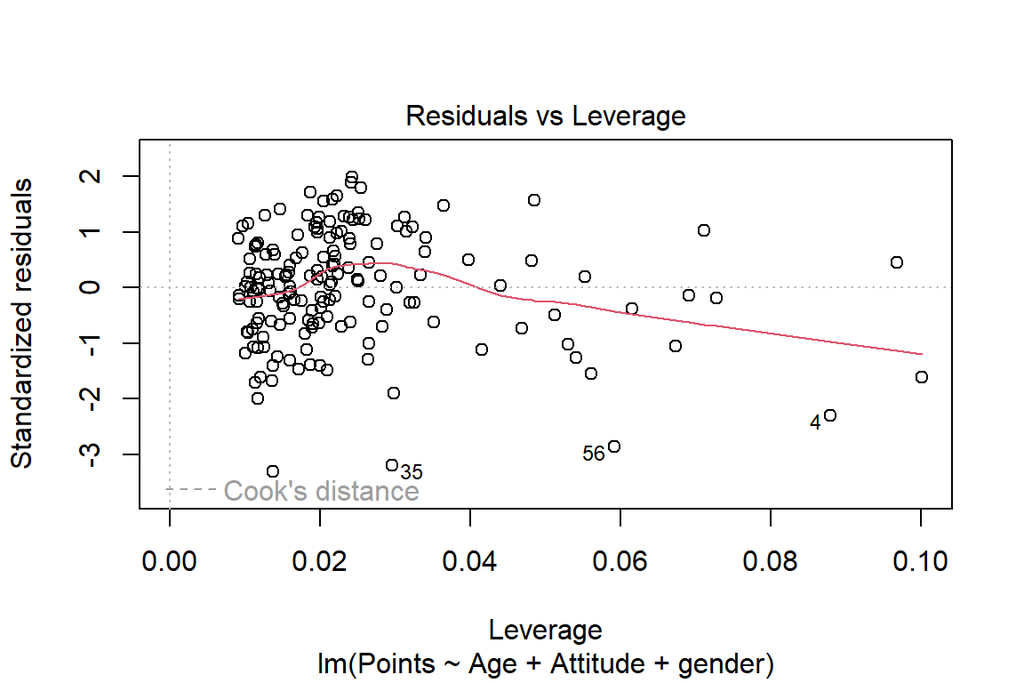

```r
# Larger plot to check Cook's distance
# (Age + Attitude + Gender vs. Points)
plot(fit_points,5)
```

(Attitude vs. Points)

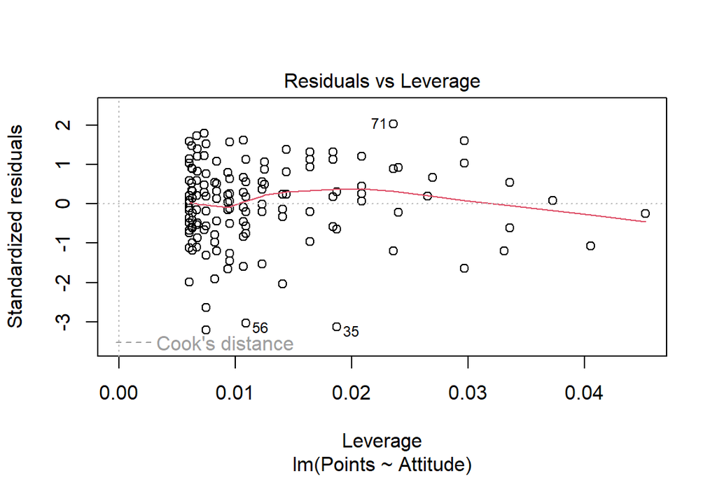

```r
# (Attitude vs. Points)
plot(fit_points2,5)
```

**Residuals vs. fitted** This plot is used to show if the residuals have non-linear patterns. As the model here is a linear model non-linear patterns would be a message that the type of model used here is a wrong one. There should be equal spread of points on the both sides of the horizontal line. No clear non-linear pattern is seen in models 1 and 2.

**Normal Q-Q** Observations should be normally distributed around fitted line seen in these plots. Here the residuals diverge from the straight line in the left and in the right side of the plot. I think the plot look reasonable good in both cases.

**Residuals vs. Leverage** The plot helps for finding outliers that can influence the model and model fit quite a lot. The model fit might improve if these outliers were excluded. Sure it is good to question what the excluded values are and it is appropriate to exclude them. The possible outliers should reside outside Cook’s distance. As seen in the plots (and additional plots) the Cook’s distance is outside the plotted field. I believe it is safe to say that the data used here have no influential outliers.

# Chapter 3, Analysis Assignment 3

The analyses used in this chapter were somewhat known to me, however, the R packages and syntax are different from other languages. Thus, it is more than possible there would be a more elegant way of doing these analyses. I do like the markdown that’s a combination of LaTeX and scripting.

Actually, today 19th of Nov I learned something new about the course, which is that there is something called Excercise Set including instructions for the assignments. Until this point, I have mainly used Google and R manual pages. Thus, it might be that the solutions below might vary somewhat from the way things are done in the course’s solutions. Maybe with the Assigment 4 I’ll first have a look at the Excercise Set 4…

```r
date()
```

```
## [1] "Tue Dec 12 11:43:53 2023"
```

## 2 Data import and check

```r
# Load libraries
suppressWarnings({
library(tidyverse)
library(readr)
library(finalfit)
library(dplyr)})
# Load data
data_alc <- read_csv("alc.csv")
# Data description
# Check the beginning of the data
head(data_alc)
```

```
## # A tibble: 6 × 35
##   school sex     age address famsize Pstatus  Medu  Fedu Mjob     Fjob    reason
##   <chr>  <chr> <dbl> <chr>   <chr>   <chr>   <dbl> <dbl> <chr>    <chr>   <chr>
## 1 GP     F        18 U       GT3     A           4     4 at_home  teacher course
## 2 GP     F        17 U       GT3     T           1     1 at_home  other   course
## 3 GP     F        15 U       LE3     T           1     1 at_home  other   other
## 4 GP     F        15 U       GT3     T           4     2 health   servic… home
## 5 GP     F        16 U       GT3     T           3     3 other    other   home
## 6 GP     M        16 U       LE3     T           4     3 services other   reput…
## # ℹ 24 more variables: guardian <chr>, traveltime <dbl>, studytime <dbl>,
## #   schoolsup <chr>, famsup <chr>, activities <chr>, nursery <chr>,
## #   higher <chr>, internet <chr>, romantic <chr>, famrel <dbl>, freetime <dbl>,
## #   goout <dbl>, Dalc <dbl>, Walc <dbl>, health <dbl>, failures <dbl>,
## #   paid <chr>, absences <dbl>, G1 <dbl>, G2 <dbl>, G3 <dbl>, alc_use <dbl>,
## #   high_use <lgl>
```

```r
# Some more indepth information regarding the data (variable types)
spec(data_alc)
# Dimensions of the data as a vector
dim_data_alc <- dim(data_alc)
dim_data_alc
```

```
## [1] 370  35
```

```r
# Missing data
# mean, sd, IQR, min/max values for appropriate variable types (numbers)
# number of categorical variables (leves_n) for charcter data
# Prints out the variable names as well. Data will be in two data frames: fisrt will have the information regarding the numeral value data and the second the variables that have character data.
ff_glimpse(data_alc)
```

```
## $Continuous
##                 label var_type   n missing_n missing_percent mean  sd  min
## age               age    <dbl> 370         0             0.0 16.6 1.2 15.0
## Medu             Medu    <dbl> 370         0             0.0  2.8 1.1  0.0
## Fedu             Fedu    <dbl> 370         0             0.0  2.6 1.1  0.0
## traveltime traveltime    <dbl> 370         0             0.0  1.4 0.7  1.0
## studytime   studytime    <dbl> 370         0             0.0  2.0 0.8  1.0
## famrel         famrel    <dbl> 370         0             0.0  3.9 0.9  1.0
## freetime     freetime    <dbl> 370         0             0.0  3.2 1.0  1.0
## goout           goout    <dbl> 370         0             0.0  3.1 1.1  1.0
## Dalc             Dalc    <dbl> 370         0             0.0  1.5 0.9  1.0
## Walc             Walc    <dbl> 370         0             0.0  2.3 1.3  1.0
## health         health    <dbl> 370         0             0.0  3.6 1.4  1.0
## failures     failures    <dbl> 370         0             0.0  0.2 0.6  0.0
## absences     absences    <dbl> 370         0             0.0  4.5 5.5  0.0
## G1                 G1    <dbl> 370         0             0.0 11.5 2.7  2.0
## G2                 G2    <dbl> 370         0             0.0 11.5 2.8  4.0
## G3                 G3    <dbl> 370         0             0.0 11.5 3.3  0.0
## alc_use       alc_use    <dbl> 370         0             0.0  1.9 1.0  1.0
##            quartile_25 median quartile_75  max
## age               16.0   17.0        17.0 22.0
## Medu               2.0    3.0         4.0  4.0
## Fedu               2.0    3.0         3.8  4.0
## traveltime         1.0    1.0         2.0  4.0
## studytime          1.0    2.0         2.0  4.0
## famrel             4.0    4.0         5.0  5.0
## freetime           3.0    3.0         4.0  5.0
## goout              2.0    3.0         4.0  5.0
## Dalc               1.0    1.0         2.0  5.0
## Walc               1.0    2.0         3.0  5.0
## health             3.0    4.0         5.0  5.0
## failures           0.0    0.0         0.0  3.0
## absences           1.0    3.0         6.0 45.0
## G1                10.0   12.0        14.0 18.0
## G2                10.0   12.0        14.0 18.0
## G3                10.0   12.0        14.0 18.0
## alc_use            1.0    1.5         2.5  5.0
##
## $Categorical
##                 label var_type   n missing_n missing_percent levels_n levels
```

[output cut: 22 more lines]

```
## famsize               -              -
## Pstatus               -              -
## Mjob                  -              -
## Fjob                  -              -
## reason                -              -
## guardian              -              -
## schoolsup             -              -
## famsup                -              -
## activities            -              -
## nursery               -              -
## higher                -              -
## internet              -              -
## romantic              -              -
## paid                  -              -
## high_use              -              -
```

Data is about alcohol consumption of students in secondary education of two Portuguese schools.

Data does have a matrix 370 (entries = persons) x 35 (columns = variables). Variables are both character variables and real numbers (double). There is one logical variable (high_use), however, several others are binary (or logical or categorical) variables but they have just imported as real numbers. There are no missing values.

Alcohol consumption (alc_use) ranges from $1.0$ to $5.0$, mean $1.9$ with sd $1.0$ and median $1.5$.

### Data description from https://archive.ics.uci.edu/dataset/320/student+performance

1 school - student’s school (binary: ‘GP’ - Gabriel Pereira or ‘MS’ - Mousinho da Silveira)

2 sex - student’s sex (binary: ‘F’ - female or ‘M’ - male)

3 age - student’s age (numeric: from 15 to 22)

4 address - student’s home address type (binary: ‘U’ - urban or ‘R’ - rural)

5 famsize - family size (binary: ‘LE3’ - less or equal to 3 or ‘GT3’ - greater than 3)

6 Pstatus - parent’s cohabitation status (binary: ‘T’ - living together or ‘A’ - apart)

7 Medu - mother’s education (numeric: 0 - none, 1 - primary education (4th grade), 2 — 5th to 9th grade, 3 — secondary education or 4 — higher education)

8 Fedu - father’s education (numeric: 0 - none, 1 - primary education (4th grade), 2 — 5th to 9th grade, 3 — secondary education or 4 — higher education)

9 Mjob - mother’s job (nominal: ‘teacher’, ‘health’ care related, civil ‘services’ (e.g. administrative or police), ‘at_home’ or ‘other’)

10 Fjob - father’s job (nominal: ‘teacher’, ‘health’ care related, civil ‘services’ (e.g. administrative or police), ‘at_home’ or ‘other’)

11 reason - reason to choose this school (nominal: close to ‘home’, school ‘reputation’, ‘course’ preference or ‘other’)

12 guardian - student’s guardian (nominal: ‘mother’, ‘father’ or ‘other’)

13 traveltime - home to school travel time (numeric: 1 - <15 min., 2 - 15 to 30 min., 3 - 30 min. to 1 hour, or 4 - >1 hour)

14 studytime - weekly study time (numeric: 1 - <2 hours, 2 - 2 to 5 hours, 3 - 5 to 10 hours, or 4 - >10 hours)

15 failures - number of past class failures (numeric: n if 1<=n<3, else 4)

16 schoolsup - extra educational support (binary: yes or no)

17 famsup - family educational support (binary: yes or no)

18 paid - extra paid classes within the course subject (Math or Portuguese) (binary: yes or no)

19 activities - extra-curricular activities (binary: yes or no)

20 nursery - attended nursery school (binary: yes or no)

21 higher - wants to take higher education (binary: yes or no)

22 internet - Internet access at home (binary: yes or no)

23 romantic - with a romantic relationship (binary: yes or no)

24 famrel - quality of family relationships (numeric: from 1 - very bad to 5 - excellent)

25 freetime - free time after school (numeric: from 1 - very low to 5 - very high)

26 goout - going out with friends (numeric: from 1 - very low to 5 - very high)

27 Dalc - workday alcohol consumption (numeric: from 1 - very low to 5 - very high)

28 Walc - weekend alcohol consumption (numeric: from 1 - very low to 5 - very high)

29 health - current health status (numeric: from 1 - very bad to 5 - very good)

30 absences - number of school absences (numeric: from 0 to 93)

these grades are related with the course subject, Math or Portuguese:

31 G1 - first period grade (numeric: from 0 to 20)

31 G2 - second period grade (numeric: from 0 to 20)

32 G3 - final grade (numeric: from 0 to 20, output target)

## 3 Variables and some plots

The four variables chosen to study with high/low alcohol comsumption (variable high_use that’s alc_use > 2): **7 Medu**, **14 studytime**, **21 higher**, and **24 famrel**.

- 7 Medu = mother’s education (numeric: 0 - none, 1 - primary education (4th grade), 2 - 5th to 9th grade, 3 - secondary education or 4 - higher education). **Hypothesis**: Mother’s education has had influence on child’s education, I reckon that higher education will decrease the alcohol consumption
- 14 studytime = weekly study time (numeric: 1 - <2 hours, 2 - 2 to 5 hours, 3 - 5 to 10 hours, or 4 - >10 hours) **Hypothesis**: Higher the studytime per week lower the alcohol consumption (no time to drink)
- 21 higher = wants to take higher education (binary: yes or no) **Hypothesis**: If student wants to have higher education, probably they would be more inclined to study and not to drink that much. Mother’s education might be a confounding factor here.
- 24 famrel = quality of family relationships (numeric: from 1 - very bad to 5 - excellent) **Hypothesis**: Better the relationships with family, less alcohol consumption.

```r
# Import libraries for the plots
suppressWarnings({
library(ggplot2)
library(GGally)
})
# Not sure if this was needed, change the number values into character values for the plots
data_alc$Medu_char <- as.character(data_alc$Medu)
data_alc$studytime_char <- as.character((data_alc$studytime))
data_alc$famrel_char <- as.character(data_alc$famrel)

# I did some investigation using the alc_use as well, thou it's not a real continuous variable (ordinal scale?)
explanatory <- c("alc_use", "Medu_char", "studytime_char", "higher", "famrel_char")

# The values in question in vector to be used later on
select_explanatory <- c("high_use", "Medu_char", "studytime_char", "higher", "famrel_char")

#data_alc %>% remove_labels() %>% ggpairs(columns = explanatory)

#data_alc %>% select(all_of(explanatory)) %>% pivot_longer(-alc_use) %>% ggplot(aes(value, alc_use)) + geom_boxplot() + facet_wrap(~name, scale = "free", ncol = 3) + coord_flip()
```

### Exploring the chosen variables using simple plots

Some simple bar plots to see how the high use of alcohol corresponds to the categories of the chosen variables. Made mainly to support the next task (no. 4).

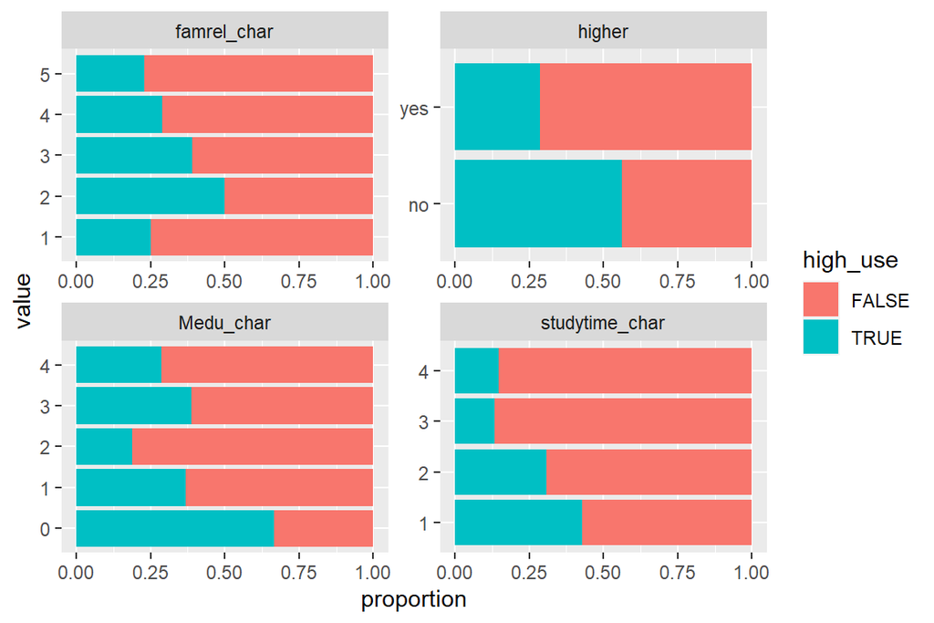

```r
# Creating a bar plot with proportional values of high_use.
data_alc %>% select(one_of(select_explanatory)) %>% pivot_longer(-high_use) %>% ggplot(aes(value, fill = high_use)) + geom_bar(position = "fill") + ylab("proportion") + facet_wrap(~name, scale = "free", ncol = 2) + coord_flip()
```

## 4 Cross tabulations

Cross tabulations for the chosen variables vs. High Use of Alcohol. Comments after tables.

```r
# Cross tabs
# Load library
suppressWarnings({library(sjPlot)})
tab_xtab(var.row = data_alc$high_use, var.col = data_alc$famrel_char, title="High Use of Alcohol vs. Family relations", show.col.prc = TRUE)
```

High Use of Alcohol vs. Family relations

| high_use | famrel_char |  |  |  |  | Total |  |
| --- | --- | --- | --- | --- | --- | --- | --- |
|  | 1 | 2 | 3 | 4 | 5 |  |  |
| FALSE | 6 75 % | 9 50 % | 39 60.9 % | 128 71.1 % | 77 77 % |  | 259 70 % |
| TRUE | 2 25 % | 9 50 % | 25 39.1 % | 52 28.9 % | 23 23 % | 111 30 % |  |
| Total | 8 100 % | 18 100 % | 64 100 % | 180 100 % | 100 100 % | 370 100 % |  |

Good family relations seem to have negative (well, one could argue that it’s positive) on high_use on alcohol. Strangely enough though, the ones with the worst family conditions seems to fare just as good as the ones with the best family conditions. Otherwise the data is consistent, the better the family conditions less high use of alcohol. The famrel groups 1 and probably 2 are small (8 and 18 students) that effects the results. Not really sure if the hypothesis holds.

```r
tab_xtab(var.row = data_alc$high_use, var.col = data_alc$higher, title="High Use of Alcohol vs. Higher education aspirations", show.col.prc = TRUE)
```

High Use of Alcohol vs. Higher education aspirations

| high_use | higher |  | Total |  |
| --- | --- | --- | --- | --- |
|  | no | yes |  |  |
| FALSE | 7 43.8 % | 252 71.2 % |  | 259 70 % |
| TRUE | 9 56.2 % | 102 28.8 % | 111 30 % |  |
| Total | 16 100 % | 354 100 % | 370 100 % |  |

Aspirations for higher education lowers the chance to have high use of alcohol. Hypothesis seems to hold. From cross-tabs it can be seen that the higher no subgroup is very small ($n=16$) compared to the yes group (n=354), which makes the results not so reliable.

```r
tab_xtab(var.row = data_alc$high_use, var.col = data_alc$Medu_char, title="High Use of Alcohol vs. Mother's education", show.col.prc = TRUE)
```

High Use of Alcohol vs. Mother’s education

| high_use | Medu_char |  |  |  |  | Total |  |
| --- | --- | --- | --- | --- | --- | --- | --- |
|  | 0 | 1 | 2 | 3 | 4 |  |  |
| FALSE | 1 33.3 % | 31 63.3 % | 78 81.2 % | 57 61.3 % | 92 71.3 % |  | 259 70 % |
| TRUE | 2 66.7 % | 18 36.7 % | 18 18.8 % | 36 38.7 % | 37 28.7 % | 111 30 % |  |
| Total | 3 100 % | 49 100 % | 96 100 % | 93 100 % | 129 100 % | 370 100 % |  |

Mother’s education does not have substantial effect on high use of alcohol, except that if mother does not have any education then students tend to use more alcohol. Again here the group 0 (no educatio) is small (n=3). After that the results are more or less the same. I think it’s difficult to prove the hypothesis with these amount of students in group 0.

```r
tab_xtab(var.row = data_alc$high_use, var.col = data_alc$studytime_char, title="High Use of Alcohol vs. Study time", show.col.prc = TRUE)
```

High Use of Alcohol vs. Study time

| high_use | studytime_char |  |  |  | Total |  |
| --- | --- | --- | --- | --- | --- | --- |
|  | 1 | 2 | 3 | 4 |  |  |
| FALSE | 56 57.1 % | 128 69.2 % | 52 86.7 % | 23 85.2 % |  | 259 70 % |
| TRUE | 42 42.9 % | 57 30.8 % | 8 13.3 % | 4 14.8 % | 111 30 % |  |
| Total | 98 100 % | 185 100 % | 60 100 % | 27 100 % | 370 100 % |  |

Study time seems to have some association with use of alcohol. The ones using more tend to study less. With cross-tabs the similar pattern can be seen.

## 5 Model fit

Using finalfit package create univariable and multivariable tables Lower values (bad family relations, no aspiration for higher education, Mother has no education, least study time) will be the references.

```r
high_use_mod <- glm(high_use ~ famrel_char + higher + Medu_char + studytime_char, data = data_alc, family = binomial)



library(finalfit)
dependent <- "high_use"
explanatory <- c("famrel_char", "higher", "Medu_char", "studytime_char")

data_alc %>% finalfit(dependent, explanatory, metrics = TRUE) -> high_use_mod2

# Nicer looking table for knit and the html file
knitr::kable(high_use_mod2[[1]], row.names=FALSE, align=c("l", "l", "r", "r", "r", "r"))
```

| Dependent: high_use |  | FALSE | TRUE | Coefficient (univariable) | Coefficient (multivariable) |
| --- | --- | --- | --- | --- | --- |
| famrel_char | 1 | 6 (75.0) | 2 (25.0) | - | - |
|  | 2 | 9 (50.0) | 9 (50.0) | 0.25 (-0.13 to 0.63, p=0.198) | 0.21 (-0.16 to 0.59, p=0.256) |
|  | 3 | 39 (60.9) | 25 (39.1) | 0.14 (-0.20 to 0.48, p=0.411) | 0.13 (-0.20 to 0.46, p=0.445) |
|  | 4 | 128 (71.1) | 52 (28.9) | 0.04 (-0.29 to 0.36, p=0.814) | 0.05 (-0.27 to 0.37, p=0.759) |
|  | 5 | 77 (77.0) | 23 (23.0) | -0.02 (-0.35 to 0.31, p=0.905) | -0.01 (-0.34 to 0.31, p=0.928) |
| higher | no | 7 (43.8) | 9 (56.2) | - | - |
|  | yes | 252 (71.2) | 102 (28.8) | -0.27 (-0.50 to -0.05, p=0.019) | -0.17 (-0.40 to 0.06, p=0.138) |
| Medu_char | 0 | 1 (33.3) | 2 (66.7) | - | - |
|  | 1 | 31 (63.3) | 18 (36.7) | -0.30 (-0.83 to 0.23, p=0.268) | -0.25 (-0.77 to 0.28, p=0.354) |
|  | 2 | 78 (81.2) | 18 (18.8) | -0.48 (-1.00 to 0.04, p=0.072) | -0.39 (-0.90 to 0.13, p=0.141) |
|  | 3 | 57 (61.3) | 36 (38.7) | -0.28 (-0.80 to 0.24, p=0.294) | -0.18 (-0.70 to 0.34, p=0.500) |
|  | 4 | 92 (71.3) | 37 (28.7) | -0.38 (-0.90 to 0.14, p=0.153) | -0.28 (-0.80 to 0.23, p=0.282) |
| studytime_char | 1 | 56 (57.1) | 42 (42.9) | - | - |
|  | 2 | 128 (69.2) | 57 (30.8) | -0.12 (-0.23 to -0.01, p=0.032) | -0.11 (-0.22 to 0.00, p=0.059) |
|  | 3 | 52 (86.7) | 8 (13.3) | -0.30 (-0.44 to -0.15, p<0.001) | -0.26 (-0.41 to -0.12, p<0.001) |
|  | 4 | 23 (85.2) | 4 (14.8) | -0.28 (-0.47 to -0.09, p=0.004) | -0.25 (-0.44 to -0.06, p=0.011) |

```r
knitr::kable(high_use_mod2[[2]], row.names=FALSE, col.names="")
```

| Number in dataframe = 370, Number in model = 370, Missing = 0, Log-likelihood = -215.8, AIC = 459.6, R-squared = 0.1, Adjusted R-squared = 0.075 |
| --- |

### Odds ratio plot

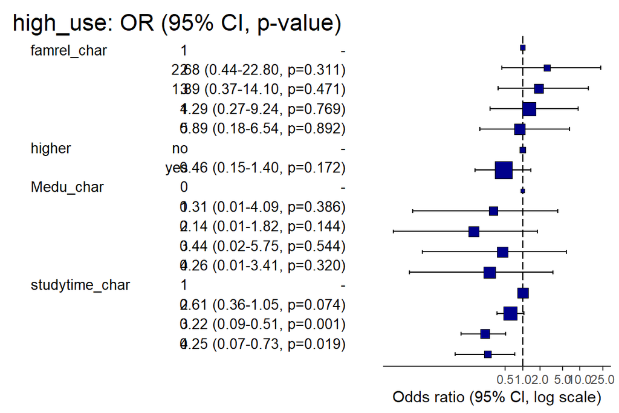

```r
# Odds ratio plot
data_alc %>% or_plot(dependent, explanatory, breaks = c(0.5, 1, 2, 5, 10, 25), table_text_size = 3.5, title_text_size = 16)
```

### Analysis of odds ratios

Model R-square is just $0.1$ and adjusted R-square $0.075$. It seems that the model ain’t that good.

## 6 model predictions

```r
# Calculate predictions using the general linear model
alc_high_pred <- predict(high_use_mod)
#alc_high_pred
#data_alc$high_use
#library(caret)

#conf_matrix <- confusionMatrix(data=alc_high_pred, reference = data_alc$high_use)

#table(data_alc$high_use, alc_high_pred)

# Some data modifications that the data and the modeled data can be compared (different data types double vs. lgl)
glm_probs <- data.frame(probs = predict(high_use_mod, type="response"))
head(glm_probs)
```

```
##       probs
## 1 0.2913594
## 2 0.2492977
## 3 0.3247049
## 4 0.1776290
## 5 0.4078263
## 6 0.2211599
```

```r
# All data that has probability >0.5 will be classified as TRUE, other FALSE

glm_pred <- glm_probs %>% mutate(pred = ifelse(probs>.5, "TRUE", "FALSE"))

glm_pred$pred_lgl <- as.logical(glm_pred$pred)
glm_pred <- cbind(data_alc, glm_pred)
```

### 2x2 cross-tabulation predicted vs. data

```r
# 2x2 cross-tabulation positives vs. negatives, confusion matrix
# Predictions as columns, data (real values) as rows
# Fill 0 might be problematic (missing values noted as 0 => false), however, here we have no missing values.
glm_pred %>% count(pred_lgl, high_use) %>% spread(high_use, n, fill = 0)
```

```
##   pred_lgl FALSE TRUE
## 1    FALSE   244   89
## 2     TRUE    15   22
```

The models sensitivity is certainly low $0.198$ that means that it is not good finding the cases where alcohol consumption is high. Specificity is better $0.942$ that means that the students with low use of alcohol will not be classified wrong as easily. I would not use this model for finding the high alcohol consumption students.

### ROC curve and AUC value

```r
suppressWarnings({library(pROC)})
# Calculating AUC and ROC
roc_score <- roc(data_alc$high_use, alc_high_pred)
```

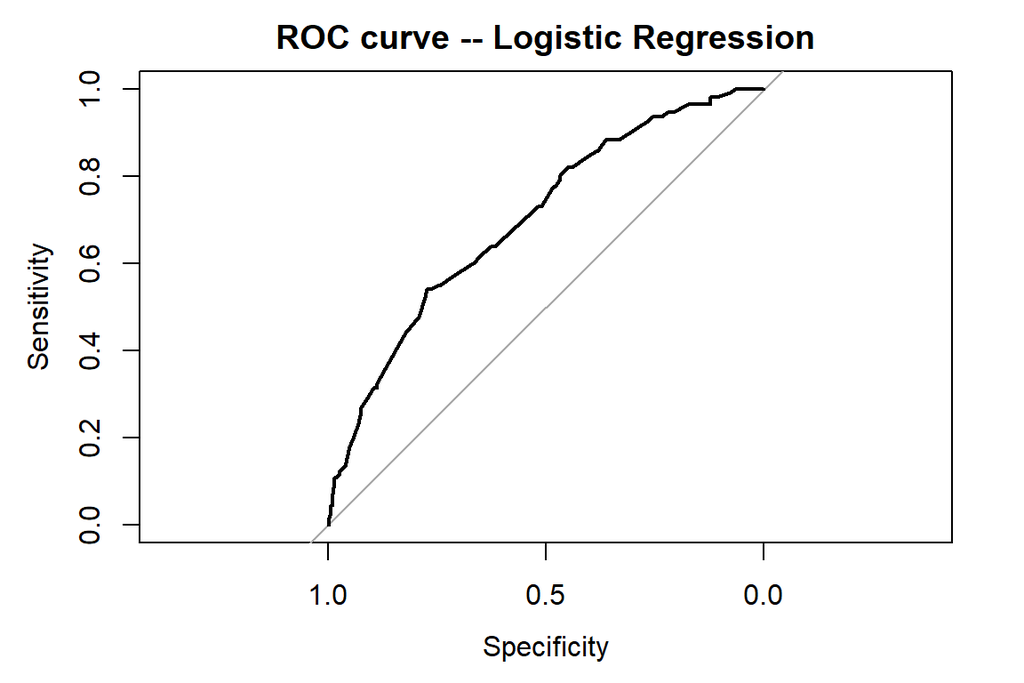

```r
plot(roc_score, main = "ROC curve -- Logistic Regression")
```

```r
roc_score # Print out AUC
```

```
##
## Call:
## roc.default(response = data_alc$high_use, predictor = alc_high_pred)
##
## Data: alc_high_pred in 259 controls (data_alc$high_use FALSE) < 111 cases (data_alc$high_use TRUE).
## Area under the curve: 0.7005
```

ROC curve can be seen above. ROC graph has Sensitivity on y-axis and Specificity (normally 1-Specificity on x-axis, in this graph x-axis is inverted) on x-axis. The diagonal line represent the uniformative classifier or model that’s no better than random. The best model in this graph would have curve going straight up from $x = 1.0$ to $y = 1.0$ and continuing rightwards at $y = 1.0$.

AUC (Area Under Curve) for the model (and predictions) is $0.70$, which is I think better than I anticipated. For random data (or uninformative classifier) the AUC should be $0.5$ (denoted but the diagonal line). Perfect model would have AUC value of $1$. Well, the model is better than random values.

# Chapter 4, Analysis Assignment 4

This week the assigments were again kinda familiar to me. I have used k-means clustering earlier, but not that many times as all kinds of regression analysis. Again, the R syntax is new. I had issues with cross tabulation data types. Finally, Google’s AI Bard gave nice hints what to do and now it seems to work. AI tools seem to make coding much more efficient.

```r
date()
```

```
## [1] "Tue Dec 12 11:43:58 2023"
```

```r
# Load libraries
suppressWarnings({
library(tidyverse)
library(readr)
library(finalfit)
library(dplyr)
library(MASS)
library(corrplot)
  })
suppressWarnings({
library(ggplot2)
library(GGally)})
```

## 2 and 3 Loading data and checking it out

```r
# Load data
data("Boston")

# Data description
# Check the beginning of the data
head(Boston)
```

```
##      crim zn indus chas   nox    rm  age    dis rad tax ptratio  black lstat
## 1 0.00632 18  2.31    0 0.538 6.575 65.2 4.0900   1 296    15.3 396.90  4.98
## 2 0.02731  0  7.07    0 0.469 6.421 78.9 4.9671   2 242    17.8 396.90  9.14
## 3 0.02729  0  7.07    0 0.469 7.185 61.1 4.9671   2 242    17.8 392.83  4.03
## 4 0.03237  0  2.18    0 0.458 6.998 45.8 6.0622   3 222    18.7 394.63  2.94
## 5 0.06905  0  2.18    0 0.458 7.147 54.2 6.0622   3 222    18.7 396.90  5.33
## 6 0.02985  0  2.18    0 0.458 6.430 58.7 6.0622   3 222    18.7 394.12  5.21
##   medv
## 1 24.0
## 2 21.6
## 3 34.7
## 4 33.4
## 5 36.2
## 6 28.7
```

```r
# Some more indepth information regarding the data (variable types)
str(Boston)
```

```
## 'data.frame':    506 obs. of  14 variables:
##  $ crim   : num  0.00632 0.02731 0.02729 0.03237 0.06905 ...
##  $ zn     : num  18 0 0 0 0 0 12.5 12.5 12.5 12.5 ...
##  $ indus  : num  2.31 7.07 7.07 2.18 2.18 2.18 7.87 7.87 7.87 7.87 ...
##  $ chas   : int  0 0 0 0 0 0 0 0 0 0 ...
##  $ nox    : num  0.538 0.469 0.469 0.458 0.458 0.458 0.524 0.524 0.524 0.524 ...
##  $ rm     : num  6.58 6.42 7.18 7 7.15 ...
##  $ age    : num  65.2 78.9 61.1 45.8 54.2 58.7 66.6 96.1 100 85.9 ...
##  $ dis    : num  4.09 4.97 4.97 6.06 6.06 ...
##  $ rad    : int  1 2 2 3 3 3 5 5 5 5 ...
##  $ tax    : num  296 242 242 222 222 222 311 311 311 311 ...
##  $ ptratio: num  15.3 17.8 17.8 18.7 18.7 18.7 15.2 15.2 15.2 15.2 ...
##  $ black  : num  397 397 393 395 397 ...
##  $ lstat  : num  4.98 9.14 4.03 2.94 5.33 ...
##  $ medv   : num  24 21.6 34.7 33.4 36.2 28.7 22.9 27.1 16.5 18.9 ...
```

```r
# Dimensions of the data as a vector
dim_Boston <- dim(Boston)
dim_Boston
```

```
## [1] 506  14
```

```r
# Summary of the whole tibble, however, below I use ff_glimpse, I think it is easier to read.
summary(Boston)
```

```
##       crim                zn             indus            chas
##  Min.   : 0.00632   Min.   :  0.00   Min.   : 0.46   Min.   :0.00000
##  1st Qu.: 0.08205   1st Qu.:  0.00   1st Qu.: 5.19   1st Qu.:0.00000
##  Median : 0.25651   Median :  0.00   Median : 9.69   Median :0.00000
##  Mean   : 3.61352   Mean   : 11.36   Mean   :11.14   Mean   :0.06917
##  3rd Qu.: 3.67708   3rd Qu.: 12.50   3rd Qu.:18.10   3rd Qu.:0.00000
##  Max.   :88.97620   Max.   :100.00   Max.   :27.74   Max.   :1.00000
##       nox               rm             age              dis
##  Min.   :0.3850   Min.   :3.561   Min.   :  2.90   Min.   : 1.130
##  1st Qu.:0.4490   1st Qu.:5.886   1st Qu.: 45.02   1st Qu.: 2.100
##  Median :0.5380   Median :6.208   Median : 77.50   Median : 3.207
##  Mean   :0.5547   Mean   :6.285   Mean   : 68.57   Mean   : 3.795
##  3rd Qu.:0.6240   3rd Qu.:6.623   3rd Qu.: 94.08   3rd Qu.: 5.188
##  Max.   :0.8710   Max.   :8.780   Max.   :100.00   Max.   :12.127
##       rad              tax           ptratio          black
##  Min.   : 1.000   Min.   :187.0   Min.   :12.60   Min.   :  0.32
##  1st Qu.: 4.000   1st Qu.:279.0   1st Qu.:17.40   1st Qu.:375.38
##  Median : 5.000   Median :330.0   Median :19.05   Median :391.44
##  Mean   : 9.549   Mean   :408.2   Mean   :18.46   Mean   :356.67
##  3rd Qu.:24.000   3rd Qu.:666.0   3rd Qu.:20.20   3rd Qu.:396.23
##  Max.   :24.000   Max.   :711.0   Max.   :22.00   Max.   :396.90
##      lstat            medv
##  Min.   : 1.73   Min.   : 5.00
##  1st Qu.: 6.95   1st Qu.:17.02
##  Median :11.36   Median :21.20
##  Mean   :12.65   Mean   :22.53
##  3rd Qu.:16.95   3rd Qu.:25.00
##  Max.   :37.97   Max.   :50.00
```

```r
# Missing data
# mean, sd, IQR, min/max values for appropriate variable types (numbers)
# number of categorical variables (leves_n) for charcter data
# Prints out the variable names as well. Data will be in two data frames: fisrt will have the information regarding the numeral value data and the second the variables that have character data.
ff_glimpse(Boston)
```

```
## $Continuous
##           label var_type   n missing_n missing_percent  mean    sd   min
## crim       crim    <dbl> 506         0             0.0   3.6   8.6   0.0
## zn           zn    <dbl> 506         0             0.0  11.4  23.3   0.0
## indus     indus    <dbl> 506         0             0.0  11.1   6.9   0.5
## chas       chas    <int> 506         0             0.0   0.1   0.3   0.0
## nox         nox    <dbl> 506         0             0.0   0.6   0.1   0.4
## rm           rm    <dbl> 506         0             0.0   6.3   0.7   3.6
## age         age    <dbl> 506         0             0.0  68.6  28.1   2.9
## dis         dis    <dbl> 506         0             0.0   3.8   2.1   1.1
## rad         rad    <int> 506         0             0.0   9.5   8.7   1.0
## tax         tax    <dbl> 506         0             0.0 408.2 168.5 187.0
## ptratio ptratio    <dbl> 506         0             0.0  18.5   2.2  12.6
## black     black    <dbl> 506         0             0.0 356.7  91.3   0.3
## lstat     lstat    <dbl> 506         0             0.0  12.7   7.1   1.7
## medv       medv    <dbl> 506         0             0.0  22.5   9.2   5.0
##         quartile_25 median quartile_75   max
## crim            0.1    0.3         3.7  89.0
## zn              0.0    0.0        12.5 100.0
## indus           5.2    9.7        18.1  27.7
## chas            0.0    0.0         0.0   1.0
## nox             0.4    0.5         0.6   0.9
## rm              5.9    6.2         6.6   8.8
## age            45.0   77.5        94.1 100.0
## dis             2.1    3.2         5.2  12.1
## rad             4.0    5.0        24.0  24.0
## tax           279.0  330.0       666.0 711.0
## ptratio        17.4   19.1        20.2  22.0
## black         375.4  391.4       396.2 396.9
## lstat           6.9   11.4        17.0  38.0
## medv           17.0   21.2        25.0  50.0
##
## $Categorical
## data frame with 0 columns and 506 rows
```

Boston tibble had 14 variables and 506 observation (rows). All variables are numbers either real numbers or integers. Data is about the housing values in the city of Boston in the US. Each row represents a Boston suburb or town.